# Election 2020 Voters Explatory Data Analysis

Steven Raimondo

22-Sep-2024

# 1 Introduction

Exploratory Data Analysis (EDA) is an important aspect of data science that focuses on summarizing and extracting key features of a dataset. This is often done through visual methods or way of summary statistics. The main objectives of EDA include:

**Understanding Data Structure**: EDA provides insights into the data’s underlying structure, such as its distribution, patterns, and anomalies

**Identifying Relationships**: It helps uncover relationships between variables

**Detecting Outliers**: It aids in identifying outliers that could impact model performance

**Checking Assumptions**: It is used to verify the assumptions necessary for statistical tests and models

By utilizing the aforementioned objectives through EDA, we’re able to determine the right techniques to extract additional insights from our data. This inevitably leads to an enhanced performance of subsequent modeling and analysis

# 2 Problem Statement & Background

In this case study, we will use publicly available data from 4 separate datasets that has been combined into one dataset to demonstrate exploratory data analysis regarding voting and supporting data surrounding the 2020 election. We will examine voting tendencies across the United States and how they are affected by way of geographically, socioeconomically, and educationally

# 3 Software System

**R (Programming Language)** was exclusively used to perform this analysis. R is an open-source and free software system for statistical computing and data visualization. The availability to all persons enables users across the globe to view, reproduce, and collaborate with ease and thus is an optimal choice for programming language to be utilized

# 4 Description of the Data

The combined dataset renamed **US_Election2020** provides an overview of winning party voting patterns across across various counties in the USA. The 4 datasets that were utilized to create the combined dataset each served it’s own purpose in feeding into the created combined dataset

**Presidential Election Data**: Only data from the 2020 election was taken from this dataset. The winning party either republican or democrat with the total votes added up were kept along with the FIPS code, state name, and county name

**Unemployment Data**: Only the unemployment date in the year 2020 or the most recent year if the 2020 unemployment rate is unavailable was used to keep the county FIPS code and the unemployment rate

**Poverty Data**: The 2019 poverty rate and county FIPS code was extracted from the poverty dataset

**Education Data**: The education levels between the years 2015 were used to keep the percent of individuals in the county FIPS who had less than a high school diploma, high school diploma, completed some college, and was a college graduate

There are several predictor variables that are crucial in this datasets EDA that will assist in predicting a winning party should subsequent in-depth analysis should be performed. The types of data that is used in assisting a model is crucial to help show how trends in the explanatory variables can affect the outcome. This dataset was built to lean on some historically important information when it comes to voters’ tendencies, some of which is the education level, unemployment, rate, and poverty rate in a particular geographical area. A detailed description of the variables is given below

# 5 Election Data

‘FIPS_Code’: Federal Information Processing Standard - A unique code that identifies counties and county equivalents in the United States

‘state’: The name of the state in the data from the United States

‘county_name’: The name of the county within the state

‘total_votes’: The number of votes the winning party received in that county

‘party’: The name of the winning political party whether it be Republican or Democrat

‘unemployment_rate’: The unemployment rate in the corresponding FIPS_code

‘poverty_rate’: The poverty rate in the corresponding FIPS_code

‘Some_High_School’: The percentage of voters in the corresponding FIPS_Code who’s highest level of education is some high school

‘High_School_Diploma’: The percentage of voters in the corresponding FIPS_Code who’s highest level of education is a high school diploma

‘Some_College’: The percentage of voters in the corresponding FIPS_Code who’s highest level of education is some college

‘College_Graduate’: The percentage of voters in the corresponding FIPS_Code who’s highest level of education is college graduate

# 6 Missing Values

The below summary table of the data indicates that the variable ‘FIPS_Code’ has 2 missing values, while ‘unemployment_rate’, ‘poverty_rate’, ,‘Some_High_School’, ‘High_School_Diploma’, ‘Some_College’, and ‘College_Graduate’ all have 41 missing values. We will impute the missing values

```r
setwd("C:/Users/frvas/Desktop/STA551/Week3")
Combined_Data <- read.csv("combined_data.csv")
US_Election2020 <- Combined_Data
summary(US_Election2020)
```

```
   FIPS_Code        state           county_name         total_votes
 Min.   : 1001   Length:3155        Length:3155        Min.   :     60
 1st Qu.:18163   Class :character   Class :character   1st Qu.:   3858
 Median :29167   Mode  :character   Mode  :character   Median :   8411
 Mean   :30287                                         Mean   :  31596
 3rd Qu.:45075                                         3rd Qu.:  21605
 Max.   :56045                                         Max.   :3028885
 NA's   :2
    party           unemployment_rate  poverty_rate   Some_High_School
 Length:3155        Min.   : 1.300    Min.   : 2.70   Min.   : 1.10
 Class :character   1st Qu.: 3.200    1st Qu.:10.40   1st Qu.: 8.50
 Mode  :character   Median : 4.100    Median :13.40   Median :11.70
                    Mean   : 4.341    Mean   :14.46   Mean   :13.08
                    3rd Qu.: 5.100    3rd Qu.:17.50   3rd Qu.:16.70
                    Max.   :17.300    Max.   :47.70   Max.   :73.60
                    NA's   :41        NA's   :41      NA's   :41
 High_School_Diploma  Some_College   College_Graduate
 Min.   : 7.30       Min.   : 5.20   Min.   : 0.00
 1st Qu.:29.70       1st Qu.:27.30   1st Qu.:15.30
 Median :34.50       Median :30.80   Median :19.60
 Mean   :34.15       Mean   :30.81   Mean   :21.96
 3rd Qu.:39.10       3rd Qu.:34.20   3rd Qu.:26.00
 Max.   :57.40       Max.   :60.60   Max.   :77.60
 NA's   :41          NA's   :41      NA's   :41
```

There are 41 rows that have missing values in the US_Election2020 dataset.The District of Columbia and the federal precinct of Rhode Island do not contain an FIPS_Code. The state of Alaska counts for 38 of the rows with a great number of missing values for the variables and the South Dakota has 1 FIPS_Code that has no data for unemployment, poverty, and education levels.

```r
Missing_Values <- US_Election2020[apply(is.na(US_Election2020), 1, any), ]
```

# 7 Dealing with Missing Values

While there is data for the District of Columbia in terms of unemployment, poverty, and education there is no FIPS_Code for the county in the election dataset we used to combine. Therefore, we can’t be certain which FIPS_Codes in the other datasets correlate with the election dataset. We will drop DC from our future analysis for this reason along with it is not a true state. Additionally, the Federal precinct of Rhode Island will be dropped as this is not a real county. We would look into possibly keeping these datapoints in future analysis should we be able to consult with a subject matter expert and get their opinion on voting election data results.

The state of Alaska has missing data for 38 of the 41 observations. The geographic isolation of the state would make imputation irresponsible as we can’t use surrounding states data to help impute. The data in Alaska very much might be significantly different than what we would hope to impute. I would further consult with a subject matter expert to help ascertain more voting information for the state and see how they correspond the the FIPS_Code as there seems to be a large amount missing in the election data. Therefore, I will remove the state of Alaska from any subsequent EDA as 3 counties will provide an inadequate amount of data to represent the state in our EDA.

Lastly, for FIPS_Code 46113: South Dakota we will impute the missing values using K-Nearest Neighbors (KNN) which utilizes the distances data points are away from each other and determines which datapoints are closest to the missing values and by impute them. For example, R will use the data in total_votes to find the nearest neighbors to FIPS_Code: 46113 and impute them as this method tells us that they should have similar values as their neighbors.

– Removing the rows that are missing values for FIPS_Code & removing Alaska from the dataset

```r
US_Election2020 <- US_Election2020[complete.cases(US_Election2020$FIPS_Code), ]

US_Election2020 <- US_Election2020[US_Election2020$state != "ALASKA", ]
```

– Filtering out South Dakota data

```r
library(dplyr)

SD_Data <- US_Election2020 %>%
  filter(state == "SOUTH DAKOTA")
```

– Using KNN to impute the missing values

```r
library(VIM)
SD_Data_I <- kNN(SD_Data, k = 5)
print(SD_Data_I[SD_Data_I$FIPS_Code == 46113, ])
```

```
   FIPS_Code        state   county_name total_votes    party unemployment_rate
51     46113 SOUTH DAKOTA OGLALA LAKOTA        2829 DEMOCRAT               7.8
   poverty_rate Some_High_School High_School_Diploma Some_College
51         39.8             15.9                35.9         32.4
   College_Graduate FIPS_Code_imp state_imp county_name_imp total_votes_imp
51             16.4         FALSE     FALSE           FALSE           FALSE
   party_imp unemployment_rate_imp poverty_rate_imp Some_High_School_imp
51     FALSE                  TRUE             TRUE                 TRUE
   High_School_Diploma_imp Some_College_imp College_Graduate_imp
51                    TRUE             TRUE                 TRUE
```

– Inputting the imputed data back into the US_Election2020 dataset and renaming it to Election2020. We will use this dataset going forth for EDA. We now see there are no more missing values. We can also look at the summary statistics and get a good idea of the data we are dealing with

```r
Update <- which(US_Election2020$FIPS_Code == 46113)
if (length(Update) > 0) {US_Election2020[Update, c("unemployment_rate", "poverty_rate", "Some_High_School", "High_School_Diploma", "Some_College", "College_Graduate")] <-
    c(7.8, 39.8, 15.9, 35.9, 32.4, 16.4)}

Election2020 <- US_Election2020

print(Election2020[Update, ])
```

```
     FIPS_Code        state   county_name total_votes    party
2426     46113 SOUTH DAKOTA OGLALA LAKOTA        2829 DEMOCRAT
     unemployment_rate poverty_rate Some_High_School High_School_Diploma
2426               7.8         39.8             15.9                35.9
     Some_College College_Graduate
2426         32.4             16.4
```

```r
summary(Election2020)
```

```
   FIPS_Code        state           county_name         total_votes
 Min.   : 1001   Length:3112        Length:3112        Min.   :     60
 1st Qu.:19041   Class :character   Class :character   1st Qu.:   3859
 Median :29210   Mode  :character   Mode  :character   Median :   8612
 Mean   :30660                                         Mean   :  31862
 3rd Qu.:46006                                         3rd Qu.:  21865
 Max.   :56045                                         Max.   :3028885
    party           unemployment_rate  poverty_rate   Some_High_School
 Length:3112        Min.   : 1.30     Min.   : 2.70   Min.   : 1.10
 Class :character   1st Qu.: 3.20     1st Qu.:10.40   1st Qu.: 8.50
 Mode  :character   Median : 4.10     Median :13.40   Median :11.70
                    Mean   : 4.34     Mean   :14.47   Mean   :13.08
                    3rd Qu.: 5.10     3rd Qu.:17.50   3rd Qu.:16.70
                    Max.   :17.30     Max.   :47.70   Max.   :73.60
 High_School_Diploma  Some_College   College_Graduate
 Min.   : 7.30       Min.   : 5.20   Min.   : 0.00
 1st Qu.:29.70       1st Qu.:27.30   1st Qu.:15.30
 Median :34.50       Median :30.80   Median :19.60
 Mean   :34.15       Mean   :30.81   Mean   :21.96
 3rd Qu.:39.10       3rd Qu.:34.20   3rd Qu.:26.00
 Max.   :57.40       Max.   :60.60   Max.   :77.60
```

# 8 Explatory Data Analysis

A good start to EDA is to look at the distribution of some key variables. We can see via the barchart below there is a lot more republican datapoints in the dataset than democrats.

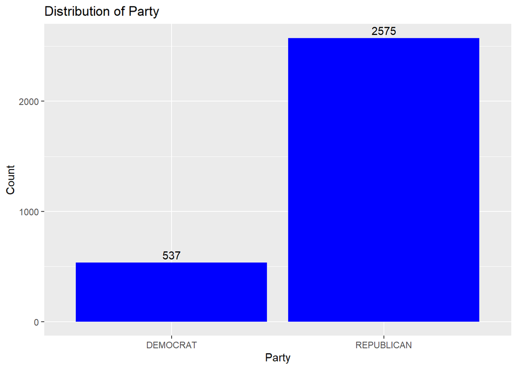

```r
library(dplyr)

ggplot(Election2020, aes(x = party)) +
 geom_bar(fill = "Blue") +
 geom_text(stat = 'count', aes(label = ..count..),  vjust = -.4,  color = "black") +
  labs(title = "Distribution of Party",
       x = "Party",
       y = "Count")
```

–However upon closer examination if we count up the total votes we see there are far more democrat total votes

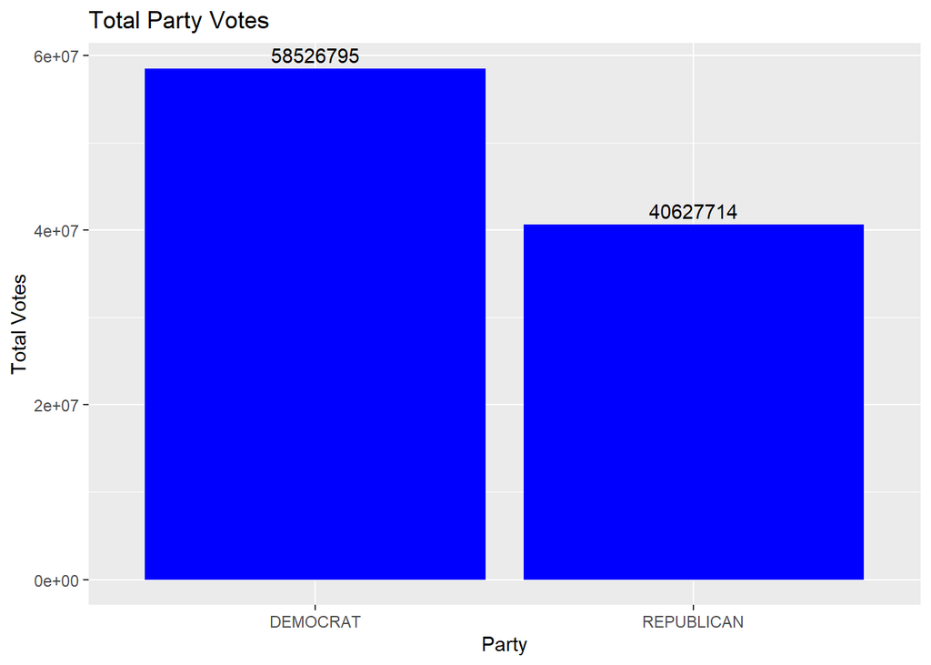

```r
library(dplyr)

Total_Party_Votes <- Election2020 %>%
  group_by(party) %>%
  summarise(total_votes = sum(total_votes, na.rm = TRUE))

ggplot(Total_Party_Votes, aes(x = party, y = total_votes, fill = party)) +
  geom_bar(fill= "Blue",stat = "identity") +
  labs(title = "Total Party Votes",
       x = "Party",
       y = "Total Votes") +
  geom_text(aes(label = total_votes), vjust = -0.4)
```

A very useful approach to EDA is understanding how each of the variables relate to one another, and we can do that by looking at how much closely they are correlated. We see as we would expect that unemployment rate and poverty rate are positively correlated. We also see that as the education level of a voter rises, both the poverty rate and unemployment rate drops.

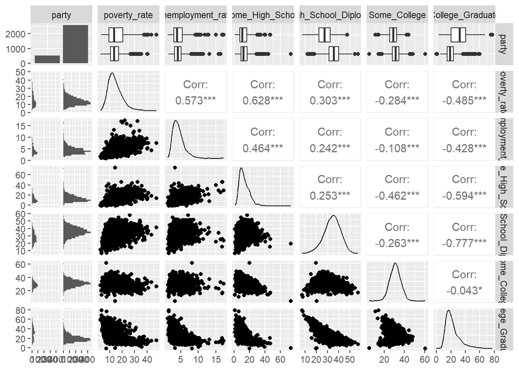

```r
library(GGally)
ggpairs(Election2020 %>% select(party, poverty_rate, unemployment_rate, Some_High_School, High_School_Diploma, Some_College, College_Graduate))
```

Looking below at the unemployment and poverty rate where either republicans or democrats won, we can see the unemployment rate is fairly similar. However, we can see the poverty rate in areas where democrats won is higher than that of republicans.

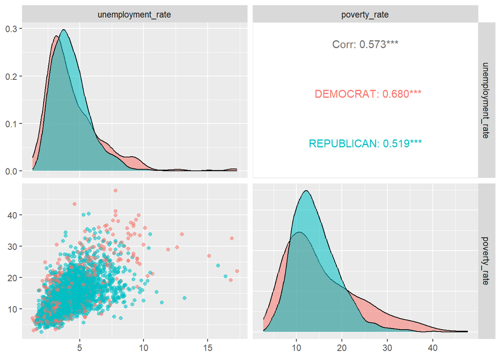

```r
library(GGally)


ggpairs(Election2020,
        columns = 6:7,
        aes(color = party, alpha = 0.5))
```

Below we can take a look at parties and look at the education levels for areas won. It appears the education levels for some high school and some college are similar in areas won by democrats and republicans. However we see that more areas of high school degree were found for republicans while more areas of college graduates were found for democrats.

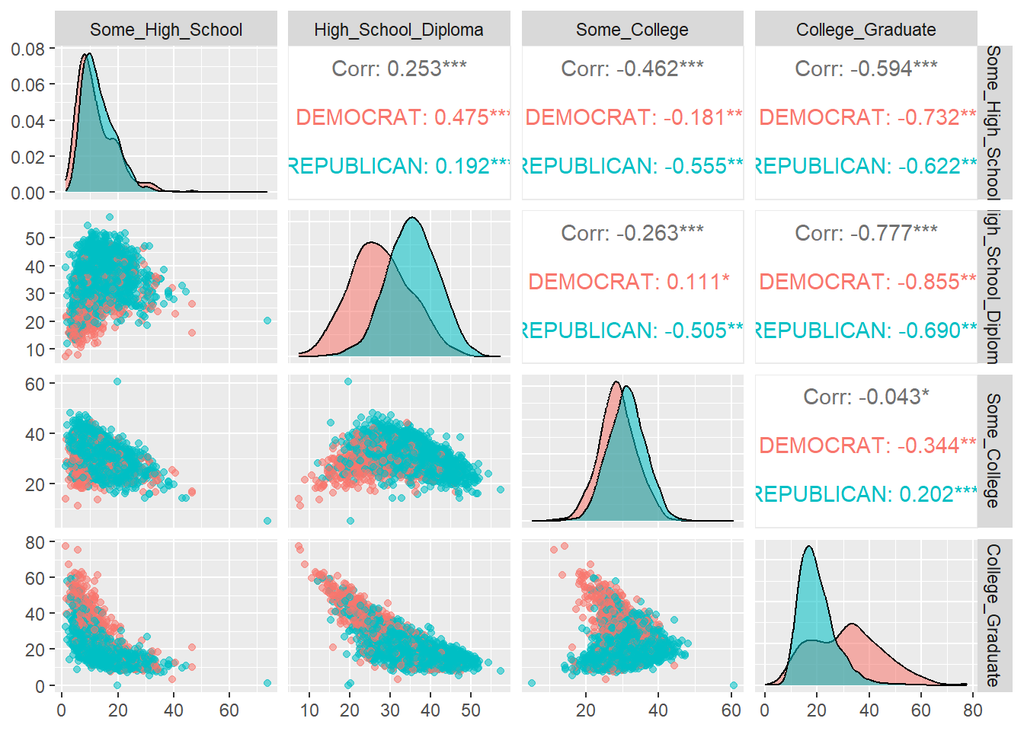

```r
library(GGally)
ggpairs(Election2020,
        columns = 8:11,
        aes(color = party, alpha = 0.5))
```

Another good way to visual data is by way of cluster plots like we saw above. However, below it’s a much clearer picture than the cluster plot with the density curves. We again see the poverty rates where democrats won higher than those of republicans while unemployment rates look fairly similar.

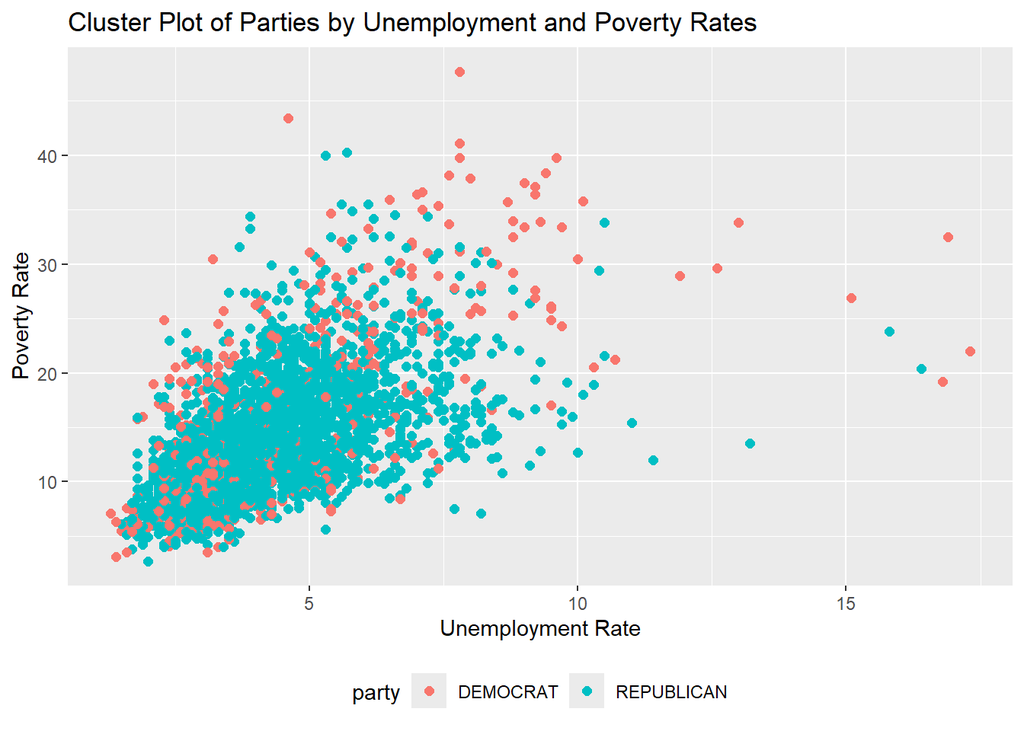

```r
library(ggplot2)
ggplot(Election2020, aes(x = unemployment_rate, y = poverty_rate, color = party)) +
  geom_point(alpha = 1, size = 2) + labs(title = "Cluster Plot of Parties by Unemployment and Poverty Rates",
       x = "Unemployment Rate",
       y = "Poverty Rate") +
  theme(legend.position = "bottom")
```

Below we look at the chisquare test of whether there is a statistically significant association between the state and the resulting winning party. The result is we see there is a very strong statistically significant relationship between states and the winning party.

```r
chisq.test(Election2020$state, Election2020$party)
```

```
    Pearson's Chi-squared test

data:  Election2020$state and Election2020$party
X-squared = 622.39, df = 48, p-value < 2.2e-16
```

# 9 Conclusion

In conclusion we can see there are many ways to perform EDA and this is just a small sample. EDA allows for the analyst to examine the data in multiple different ways to try to ascertain what the data is showing them in a simple way. We see that while many of the areas resulted in a republican win the democrat total votes surpassed the republicans by far. This lends itself to the idea that cities tend to vote more democrat and rural areas lean more towards republicans. We also see evidence of that by way of higher poverty rates in democratic areas where we can hypothesize these are more city areas. In terms of poverty and unemployment rates we saw there was an inverse relationship between these rates and education levels.

# 10 Appendix - R Code

Below I’m setting the working directory and loading the 4 datasets I plan to use to combine into 1 dataset.

```r
setwd("C:/Users/frvas/Desktop/STA551/Week3")
Election <- read.csv("countypresidential_election_2000-2020.csv")
Education <- read.csv("Education.csv")
Poverty <- read.csv("PovertyEstimates.csv")
Unemployment1 <- read.csv("Unemployment.csv")
```

Next I’m loading the library dplyr to assist with extracting the data I want from the **Election** dataset. - Rename the dataset as to not alter the original - Filter and keep only data rows that have 2020 in the year column - Filter and keep only data rows that have Democrat or Republican in the party column - Add up the total votes by county and part - Determine the winning party based on total votes and keep the winning party along with county_fips, state, county_name information - Look at the 1st 5 entries of the new dataset. I’m hiding the output with results=FALSE to make it cleaner to read for the final document.

```r
library(dplyr)

Election_2020 <- Election %>%
  filter(year == 2020) %>%
  filter(party == "DEMOCRAT" | party == "REPUBLICAN") %>%
  group_by(state, county_name, county_fips, party) %>%
  summarise(total_votes = sum(candidatevotes), .groups = 'drop') %>%
  group_by(state, county_name, county_fips) %>%
  slice(which.max(total_votes)) %>%
  select(county_fips, state, county_name, total_votes, party)

head(Election_2020,5)
```

Next I’m extracting the data I want from the **Unemployment1** dataset. - Rename the dataset as to not alter the original - Extracting the year from the Attribute column - Filter and keep rows that have unemployment_rate - Group by FIPS and summarize by year and keep if 2020 or else keep the max year - Select columns want to keep: FIPS_Code, year, value - Look at the 1st 5 entries of the new dataset. I’m hiding the output with results=FALSE to make it cleaner to read for the final document.

```r
unemployment_data <- Unemployment1 %>%
  mutate(year = as.numeric(sapply(strsplit(Attribute, "_"), tail, 1))) %>%
  filter(grepl("Unemployment_rate", Attribute)) %>%
  group_by(FIPS_Code) %>%
  summarize(year = if_else(any(year == 2020), 2020, max(year[year < 2020], na.rm = TRUE)),
  Value = Value[which.max(year)]) %>%
  select(FIPS_Code, year, Value)

head(unemployment_data,5)
```

Next I’m extracting the data I want from the **Poverty** dataset. - Rename the dataset as to not alter the original - Filter and keep only data rows that have ’PCTPOVALL_2019 in the Attribute column - Select which columns to keep and rename FIPStxt to County_FIPS - Look at the 1st 5 entries of the new dataset. I’m hiding the output with results=FALSE to make it cleaner to read for the final document.

```r
Poverty_2019 <- Poverty %>%
  filter(Attribute == "PCTPOVALL_2019") %>%
  select(FIPStxt, Value) %>%
  rename(County_FIPS = FIPStxt)

head(Poverty_2019,5)
```

```r
Education_Data <- Education %>%
  select(
    FIPS.Code,
    Percent.of.adults.with.less.than.a.high.school.diploma..2015.19,
    Percent.of.adults.with.a.high.school.diploma.only..2015.19,
    Percent.of.adults.completing.some.college.or.associate.s.degree..2015.19,
    Percent.of.adults.with.a.bachelor.s.degree.or.higher..2015.19
  ) %>%
  rename(
    County_FIPS = FIPS.Code,
    Some_High_School = Percent.of.adults.with.less.than.a.high.school.diploma..2015.19,
    High_School_Diploma = Percent.of.adults.with.a.high.school.diploma.only..2015.19,
    Some_College = Percent.of.adults.completing.some.college.or.associate.s.degree..2015.19,
    College_Graduate = Percent.of.adults.with.a.bachelor.s.degree.or.higher..2015.19
  )
head(Education_Data,5)
```

```
  County_FIPS Some_High_School High_School_Diploma Some_College
1           0             12.0                27.0         28.9
2        1000             13.8                30.8         29.9
3        1001             11.5                33.6         28.4
4        1003              9.2                27.7         31.3
5        1005             26.8                35.6         26.0
  College_Graduate
1             32.1
2             25.5
3             26.6
4             31.9
5             11.6
```

Next I’m combining the 4 datasets to make 1 combined dataset called **combined_data** - Using sql to combine the 4 datasets into 1 while renaming the variables so they match - Look at the 1st 5 entries of the new dataset along w/ the summary of the dataset I’m hiding the output with results=FALSE to make it cleaner to read for the final document.

```r
library(sqldf)
combined_data <- sqldf("
SELECT
  Election_2020.county_fips AS FIPS_Code,
  Election_2020.state,
  Election_2020.county_name,
  Election_2020.total_votes,
  Election_2020.party,
  unemployment_data.value AS unemployment_rate,
  Poverty_2019.Value AS poverty_rate,
  Education_Data.Some_High_School,
  Education_Data.High_School_Diploma,
  Education_Data.Some_College,
  Education_Data.College_Graduate
FROM Election_2020
  LEFT JOIN
   unemployment_data ON Election_2020.county_fips = unemployment_data.FIPS_Code
  LEFT JOIN
    Poverty_2019 ON Election_2020.county_fips = Poverty_2019.County_FIPS
  LEFT JOIN
    Education_Data ON Election_2020.county_fips = Education_Data.County_FIPS")

head(combined_data,5)
summary(combined_data)
```